# Linear Regression with mtcars dataset

14 Februar 2019

## Overview

This presentation gives an overview about a RStudio shiny application, that was developed as a part of the week4-project in the Developing Data Products course on coursera.

The application ist hosted on: https://bhuntge.shinyapps.io/ProjectLmMtcars/  
The code (ui.R, server.R) is also on github: https://github.com/bhuntgeb/coursera_developing_data_products

The application includes:  
- The use of the mtcars dataset to do a linear regression for mpg as outcome  
- Input values to subset the data for min/max values of the predictors (wt + cyl)  
- Create scatter plots of the data and adds the fitted regression line

## Short description of the Data Product

- The slider inputs set the min/max values of the wt-feature to subset the data
- The min/max values are indicated by the red lines
- This is the produced scatter plot

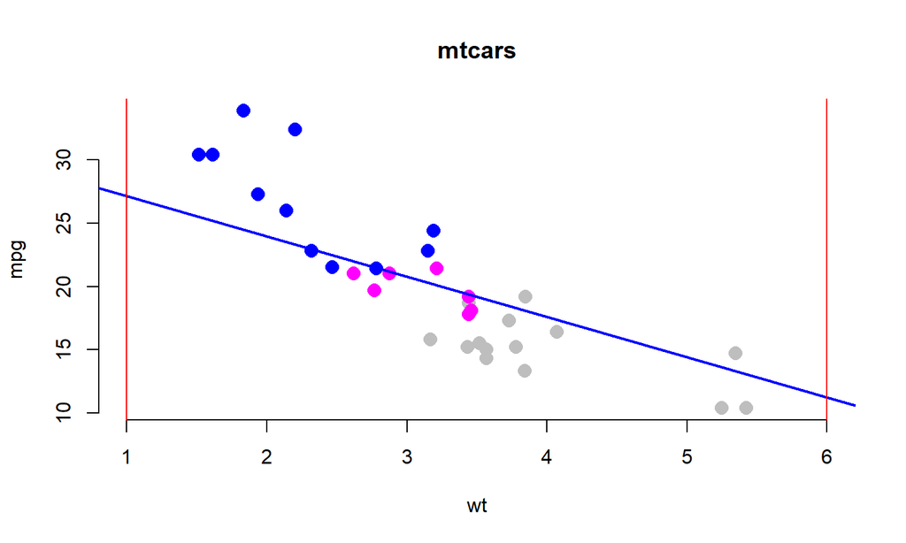

## The ui.R Frontend

- The ui.R frontend has several input values in a side panel

```r
sidebarLayout(
  sidebarPanel(
    h2("Get started!"), p("Some description....  ",
    # some input values
    sliderInput("sliderWt", "Weight value", 1, 6, value = c(1, 6), step = 0.1),
    sliderInput("sliderCyl", "Cylinders value", 3, 9, value = c(3, 9), step = 0.1)
  ),
  ...
```

- … and several text outputs and plots on the main panel

  ```r
  mainPanel(
    # some output value
    h3("Regression coefficients"),
    p("Intercept: ",textOutput("intOutWt", inline = TRUE)),
    p("Slope of 'wt' coefficient:",textOutput("slopeOutWt", inline = TRUE)),
    <.....>
    # A tabset with two tabs, that display plot outputs
    tabsetPanel(type = "tabs",
  tabPanel("MPG vs. Wt", br(), plotOutput("plot1")),
  tabPanel("MPG vs. Cyl", br(), plotOutput("plot2"))
  )
  ```

## The server.R Backend

- The 'reactive' function reads input values and does the linear regression

```r
model<-reactive({
  cylMin<-input$sliderCyl[1],  cylMax<-input$sliderCyl[2]  # Read the slider input
  wtMin<-input$sliderWt[1],   wtMax<-input$sliderWt[2]
  # subset the mtcars dataset
  subCyl<-mtcars[(mtcars$cyl< cylMax)& (mtcars$cyl> cylMin),]
  subWt<-mtcars[(mtcars$wt< wtMax)& (mtcars$wt> wtMin),]
  subData<-intersect(subCyl, subWt)
  # train a lines regression
  fit<-lm(mpg ~ wt + cyl, data = subData)
  fit })
```

- The scatter plot is rendered and sent to the ui.R frontend

```r
  output$plot1 <- renderPlot({
          # Scatterplot
          plot(mtcars$wt, mtcars$mpg, xlab = "wt",
               ylab = "mpg", main = "mtcars", xlim = c(1,6),
               cex = 1.5, pch = 16, bty = "n", col=mtcars$cyl)
          # Draw fitted and min/max lines
          abline(a=....., b= ...., col = "blue", lwd = 2)
          abline(v=input$sliderWt[2], col ="red")
          abline(v=input$sliderWt[1], col ="red")
  })
```